# 数据及项目简介：

我们对红葡萄酒数据集进行分析 这个数据集包含1,599 种红酒，以及 11 个关于酒的化学成分的变量。 至少 3 名葡萄酒专家对每种酒的质量进行了评分，分数在 0（非常差）和10（非常好）之间。 我们将通过分析以得知哪些化学成分影响红葡萄酒的质量

```python
import pandas as pd
from ggplot import *
import seaborn as sns
%matplotlib inline
```

```python
df = pd.read_csv('wineQualityReds.csv')
```

```python
df.head()
```

|  | Unnamed: 0 | fixed.acidity | volatile.acidity | citric.acid | residual.sugar | chlorides | free.sulfur.dioxide | total.sulfur.dioxide | density | pH | sulphates | alcohol | quality |
| --- | --- | --- | --- | --- | --- | --- | --- | --- | --- | --- | --- | --- | --- |
| 0 | 1 | 7.4 | 0.70 | 0.00 | 1.9 | 0.076 | 11.0 | 34.0 | 0.9978 | 3.51 | 0.56 | 9.4 | 5 |
| 1 | 2 | 7.8 | 0.88 | 0.00 | 2.6 | 0.098 | 25.0 | 67.0 | 0.9968 | 3.20 | 0.68 | 9.8 | 5 |
| 2 | 3 | 7.8 | 0.76 | 0.04 | 2.3 | 0.092 | 15.0 | 54.0 | 0.9970 | 3.26 | 0.65 | 9.8 | 5 |
| 3 | 4 | 11.2 | 0.28 | 0.56 | 1.9 | 0.075 | 17.0 | 60.0 | 0.9980 | 3.16 | 0.58 | 9.8 | 6 |
| 4 | 5 | 7.4 | 0.70 | 0.00 | 1.9 | 0.076 | 11.0 | 34.0 | 0.9978 | 3.51 | 0.56 | 9.4 | 5 |

```python
df.shape
```

```
(1599, 13)
```

```python
df.info()
```

```
<class 'pandas.core.frame.DataFrame'>
RangeIndex: 1599 entries, 0 to 1598
Data columns (total 13 columns):
Unnamed: 0              1599 non-null int64
fixed.acidity           1599 non-null float64
volatile.acidity        1599 non-null float64
citric.acid             1599 non-null float64
residual.sugar          1599 non-null float64
chlorides               1599 non-null float64
free.sulfur.dioxide     1599 non-null float64
total.sulfur.dioxide    1599 non-null float64
density                 1599 non-null float64
pH                      1599 non-null float64
sulphates               1599 non-null float64
alcohol                 1599 non-null float64
quality                 1599 non-null int64
dtypes: float64(11), int64(2)
memory usage: 162.5 KB
```

```python
df.info()
```

```
<class 'pandas.core.frame.DataFrame'>
RangeIndex: 1599 entries, 0 to 1598
Data columns (total 13 columns):
Unnamed: 0              1599 non-null int64
fixed.acidity           1599 non-null float64
volatile.acidity        1599 non-null float64
citric.acid             1599 non-null float64
residual.sugar          1599 non-null float64
chlorides               1599 non-null float64
free.sulfur.dioxide     1599 non-null float64
total.sulfur.dioxide    1599 non-null float64
density                 1599 non-null float64
pH                      1599 non-null float64
sulphates               1599 non-null float64
alcohol                 1599 non-null float64
quality                 1599 non-null int64
dtypes: float64(11), int64(2)
memory usage: 162.5 KB
```

```python
df.describe()
```

|  | Unnamed: 0 | fixed.acidity | volatile.acidity | citric.acid | residual.sugar | chlorides | free.sulfur.dioxide | total.sulfur.dioxide | density | pH | sulphates | alcohol | quality |
| --- | --- | --- | --- | --- | --- | --- | --- | --- | --- | --- | --- | --- | --- |
| count | 1599.000000 | 1599.000000 | 1599.000000 | 1599.000000 | 1599.000000 | 1599.000000 | 1599.000000 | 1599.000000 | 1599.000000 | 1599.000000 | 1599.000000 | 1599.000000 | 1599.000000 |
| mean | 800.000000 | 8.319637 | 0.527821 | 0.270976 | 2.538806 | 0.087467 | 15.874922 | 46.467792 | 0.996747 | 3.311113 | 0.658149 | 10.422983 | 5.636023 |
| std | 461.735855 | 1.741096 | 0.179060 | 0.194801 | 1.409928 | 0.047065 | 10.460157 | 32.895324 | 0.001887 | 0.154386 | 0.169507 | 1.065668 | 0.807569 |
| min | 1.000000 | 4.600000 | 0.120000 | 0.000000 | 0.900000 | 0.012000 | 1.000000 | 6.000000 | 0.990070 | 2.740000 | 0.330000 | 8.400000 | 3.000000 |
| 25% | 400.500000 | 7.100000 | 0.390000 | 0.090000 | 1.900000 | 0.070000 | 7.000000 | 22.000000 | 0.995600 | 3.210000 | 0.550000 | 9.500000 | 5.000000 |
| 50% | 800.000000 | 7.900000 | 0.520000 | 0.260000 | 2.200000 | 0.079000 | 14.000000 | 38.000000 | 0.996750 | 3.310000 | 0.620000 | 10.200000 | 6.000000 |
| 75% | 1199.500000 | 9.200000 | 0.640000 | 0.420000 | 2.600000 | 0.090000 | 21.000000 | 62.000000 | 0.997835 | 3.400000 | 0.730000 | 11.100000 | 6.000000 |
| max | 1599.000000 | 15.900000 | 1.580000 | 1.000000 | 15.500000 | 0.611000 | 72.000000 | 289.000000 | 1.003690 | 4.010000 | 2.000000 | 14.900000 | 8.000000 |

# 单变量绘图选择

## 查看酒的质量的评分分布：

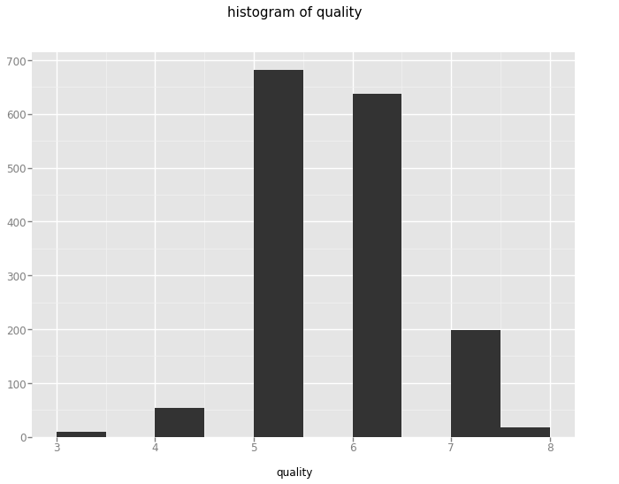

```python
ggplot(aes(x = 'quality'), data = df) + geom_histogram() + \
ggtitle(element_text(text='histogram of quality', size=15))
```

**从上图可以看出，质量基本呈正态分布**

## 查看fixed.acidity的分布：

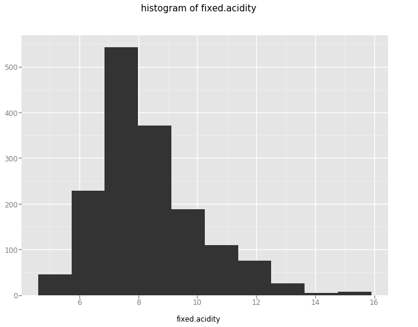

```python
ggplot(aes(x = 'fixed.acidity'), data = df) + geom_histogram() + \
ggtitle(element_text(text='histogram of fixed.acidity', size=15))
```

**上图表明fixed.acidity呈右偏分布,大多数在6~12之间。**

## volatile.acidity也呈右偏分布，但其中有异常值，大多数值在0.25~1之间，我们取其前99%的数绘图：

```python
df_volatile = df[df['volatile.acidity'] < df['volatile.acidity'].quantile(.99)]
```

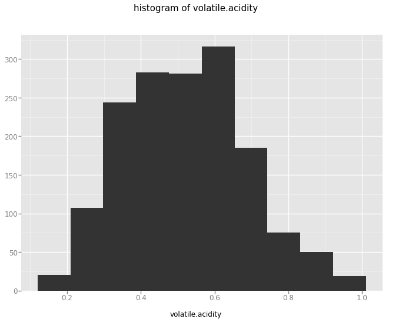

```python
ggplot(aes(x = 'volatile.acidity'), data = df_volatile) + geom_histogram() + \
ggtitle(element_text(text='histogram of volatile.acidity', size=15))
```

**上图可以看到，去掉异常值后，volatile.acidity呈正态分布。**

## 查看citric.acid的分布：

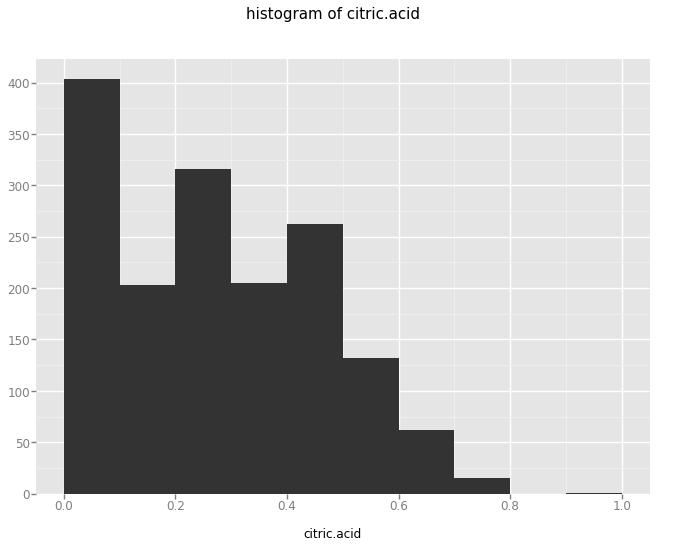

```python
ggplot(aes(x = 'citric.acid'), data = df) + geom_histogram() + \
ggtitle(element_text(text='histogram of citric.acid', size=15))
```

## 查看residual.sugar的分布：

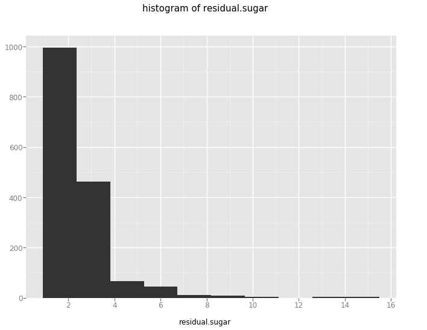

```python
ggplot(aes(x = 'residual.sugar'), data = df) + geom_histogram() + \
ggtitle(element_text(text='histogram of residual.sugar', size=15))
```

## 查看chlorides的分布：

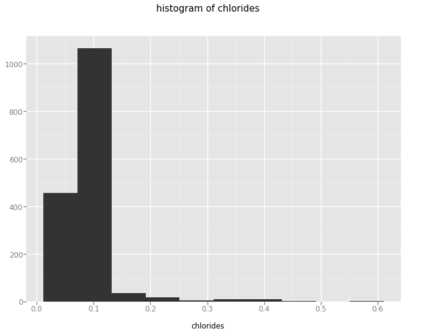

```python
ggplot(aes(x = 'chlorides'), data = df) + geom_histogram() + \
ggtitle(element_text(text='histogram of chlorides', size=15))
```

**chlorides的大多数值分布集中，少量值严重右偏，取其前95%的值:**

```python
df_chlorides = df[df['chlorides'] < df['chlorides'].quantile(.95)]
```

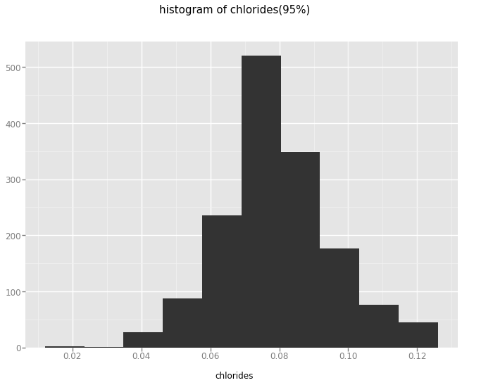

```python
ggplot(aes(x = 'chlorides'), data = df_chlorides) + geom_histogram() + \
ggtitle(element_text(text='histogram of chlorides(95%)', size=15))
```

**转换后呈右偏正态分布**

## 查看total.sulfur.dioxide的分布形态：

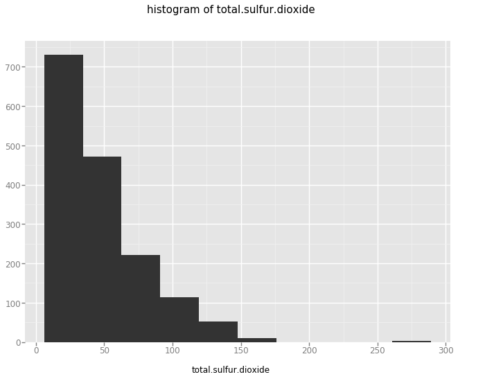

```python
ggplot(aes(x = 'total.sulfur.dioxide'), data = df) + geom_histogram() + \
ggtitle(element_text(text='histogram of total.sulfur.dioxide', size=15))
```

```python
df_sulfur_dioxide = df[df['total.sulfur.dioxide'] < df['total.sulfur.dioxide'].quantile(.99)]
```

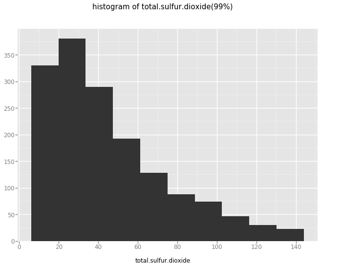

```python
ggplot(aes(x = 'total.sulfur.dioxide'), data = df_sulfur_dioxide) + geom_histogram() + \
ggtitle(element_text(text='histogram of total.sulfur.dioxide(99%)', size=15))
```

## 查看density的分布：

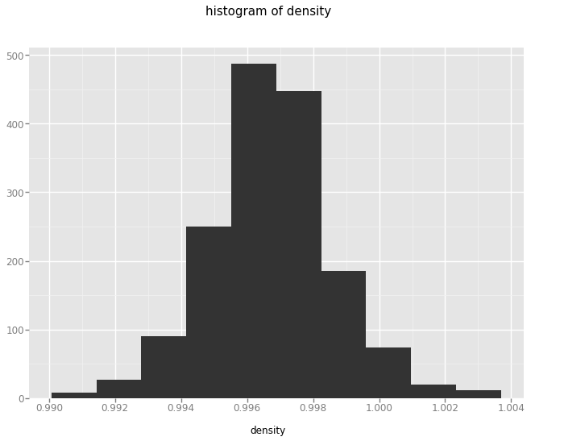

```python
ggplot(aes(x = 'density'), data = df) + geom_histogram() + \
ggtitle(element_text(text='histogram of density', size=15))
```

**density基本呈标准正态分布**

## 查看PH分布：

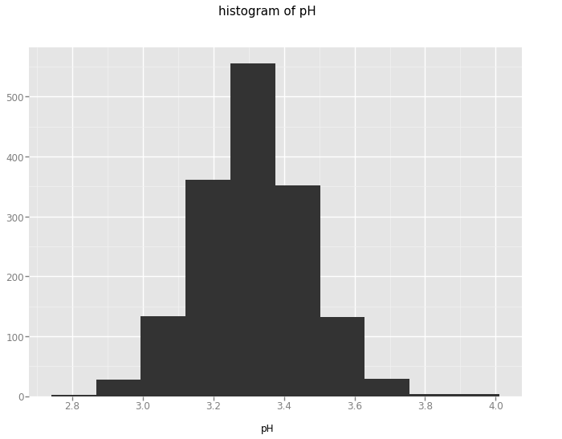

```python
ggplot(aes(x = 'pH'), data = df) + geom_histogram() + \
ggtitle(element_text(text='histogram of pH', size=15))
```

**PH也基本呈标准正态分布**

## 查看sulphates的分布：

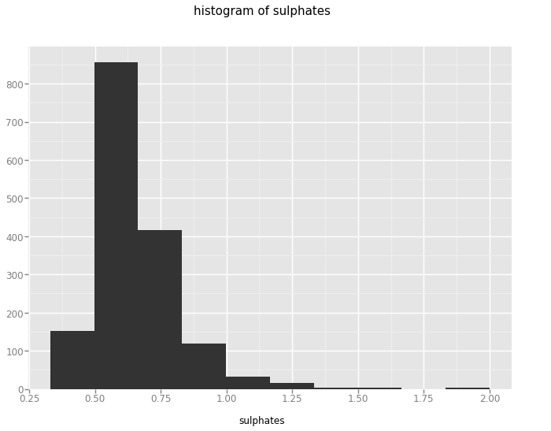

```python
ggplot(aes(x = 'sulphates'), data = df) + geom_histogram() + \
ggtitle(element_text(text='histogram of sulphates', size=15))
```

## 查看alcohol的分布形态：

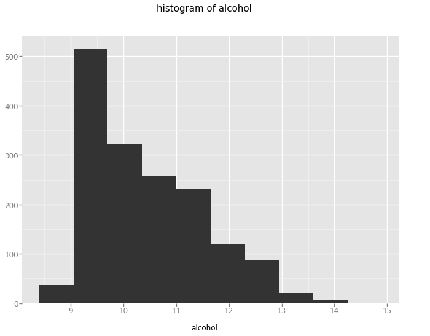

```python
ggplot(aes(x = 'alcohol'), data = df) + geom_histogram() + \
ggtitle(element_text(text='histogram of alcohol', size=15))
```

**alcohol呈右偏正态分布**

# 单变量分析

## 你的数据集结构是什么？

**数据集有1599个观测值，有12个特征，除了质量是整数型，其它都是浮点型。**

## 你的数据集内感兴趣的主要特性有哪些？

**主要有质量，固定酸度，游离酸度，柠檬酸，残糖**

## 你认为数据集内哪些其他特征可以帮助你探索兴趣特点？

**我觉得PH及酒精也有影响**

## 根据数据集内已有变量，你是否创建了任何新变量？

**没有创建新的变量**

## 在已经探究的特性中，是否存在任何异常分布？你是否对数据进行一些操作，如清洁、调整或改变数据的形式？如果是，你为什么会这样做？

**游离酸度有异常值，对其取前99%的数据，残糖呈现长尾分布，总二氧化硫有异常值，取前99%的数。**

# 双变量绘图选择

## 查看fixed.acidity和quality的关系：

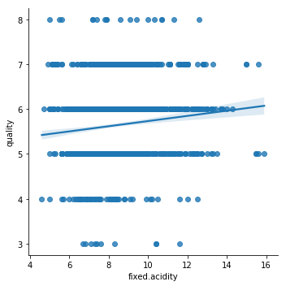

```python
g = sns.lmplot(x="fixed.acidity", y= "quality", truncate=True, size=5,data=df)
```

```python
df['fixed.acidity'].corr(df['quality'])
```

```
0.12405164911322429
```

**从分布看，fixed.acidity值的主要区间中quality基本均匀分布，计算相关系数后两者没有明显关系**

## 查看volatile.acidity和quality的关系：

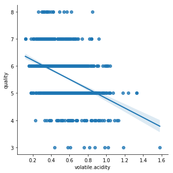

```python
g = sns.lmplot(x="volatile.acidity", y= "quality", truncate=True, size=5,data=df)
```

```python
df['volatile.acidity'].corr(df['quality'])
```

```
-0.3905577802640073
```

**volatile.acidity和quality的相关系数为-0.39，与分布的观察结果一致**

## 查看citric.acid和质量的关系：

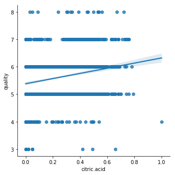

```python
g = sns.lmplot(x="citric.acid", y= "quality", truncate=True, size=5,data=df)
```

```python
df['citric.acid'].corr(df['quality'])
```

```
0.22637251431804145
```

**看不出有明显的相关性**

## 查看residual.sugar和quality的相关性：

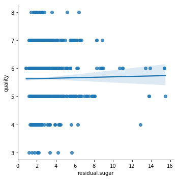

```python
g = sns.lmplot(x="residual.sugar", y= "quality", truncate=True, size=5,data=df)
```

```python
df['residual.sugar'].corr(df['quality'])
```

```
0.013731637340066275
```

**没有相关性**

## 查看chlorides和Quality的相关性：

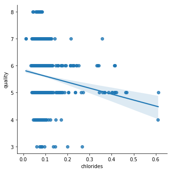

```python
g = sns.lmplot(x="chlorides", y= "quality", truncate=True, size=5,data=df)
```

```python
df['chlorides'].corr(df['quality'])
```

```
-0.12890655993005273
```

**看不出有相关性**

## 查看free.sulfur.dioxide和quality的相关性：

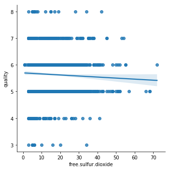

```python
g = sns.lmplot(x="free.sulfur.dioxide", y= "quality", truncate=True, size=5,data=df)
```

```python
df['free.sulfur.dioxide'].corr(df['quality'])
```

```
-0.050656057244276353
```

**明显没有相关性**

## 查看total.sulfur.dioxide和quality的相关性：

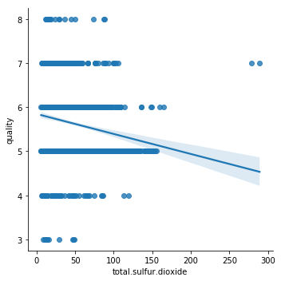

```python
g = sns.lmplot(x="total.sulfur.dioxide", y= "quality", truncate=True, size=5,data=df)
```

```python
df['total.sulfur.dioxide'].corr(df['quality'])
```

```
-0.18510028892653788
```

**没有相关性**

## 查看density和quality的相关性

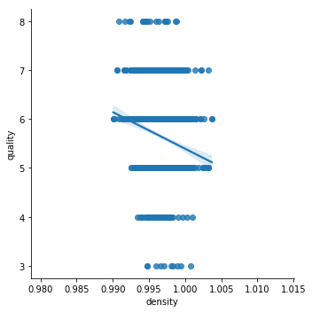

```python
g = sns.lmplot(x="density", y= "quality", truncate=True, size=5,data=df)
```

```python
df['density'].corr(df['quality'])
```

```
-0.1749192277833501
```

**没有相关性**

## 查看pH和quality的关系：

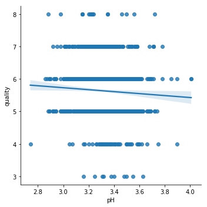

```python
g = sns.lmplot(x="pH", y= "quality", truncate=True, size=5,data=df)
```

```python
df['pH'].corr(df['quality'])
```

```
-0.05773139120538214
```

## 查看alcohol和quality的相关性：

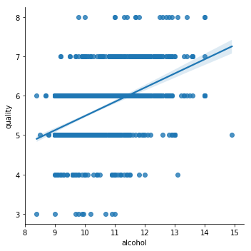

```python
g = sns.lmplot(x="alcohol", y= "quality", truncate=True, size=5,data=df)
```

```python
df['alcohol'].corr(df['quality'])
```

```
0.4761663240011362
```

**alcohol和quality存在相关性**

# 双变量分析

## 探讨你在这部分探究中观察到的一些关系。这些感兴趣的特性与数据集内其他特性有什么区别？

**质量与游离酸度及酒精度相关，而游离酸度又与柠檬酸相关，酒精度和密度相关**

## 你是否观察到主要特性与其他特性之间的有趣关系？

**质量与游离酸度及酒精度相关**

## 你发现最强的关系是什么？

**alcohol与quality的相关度最强，相关系数为0.47**

# 多变量绘图选择

## 查看citric.acid， volatile.acidity， quality间的关系：

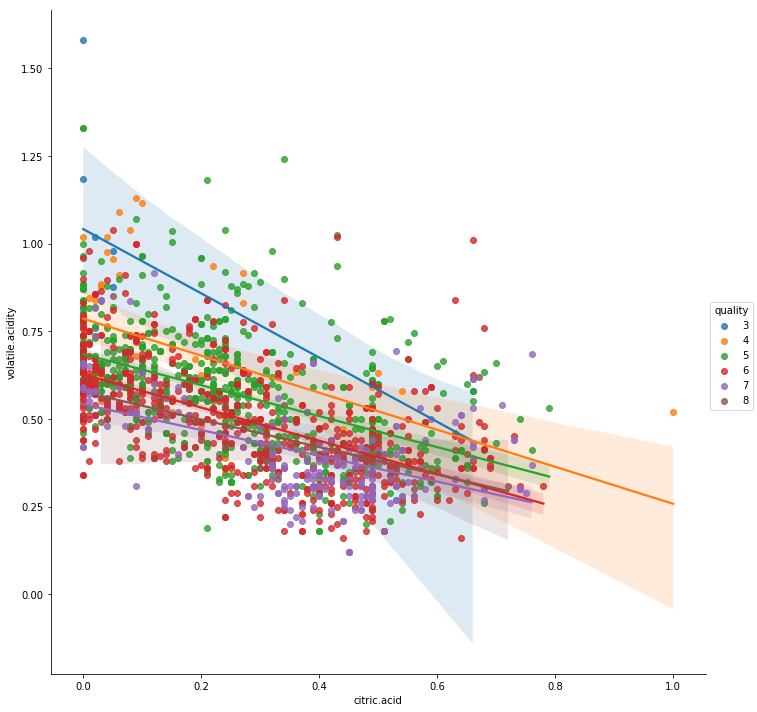

```python
g = sns.lmplot(x="citric.acid", y="volatile.acidity", hue="quality",
               truncate=True, size=10, data=df)
```

**不同的质量下，citric.acid和volatile.acidity成负相关**

## 查看alcohol， pH， quality变量间的关系：

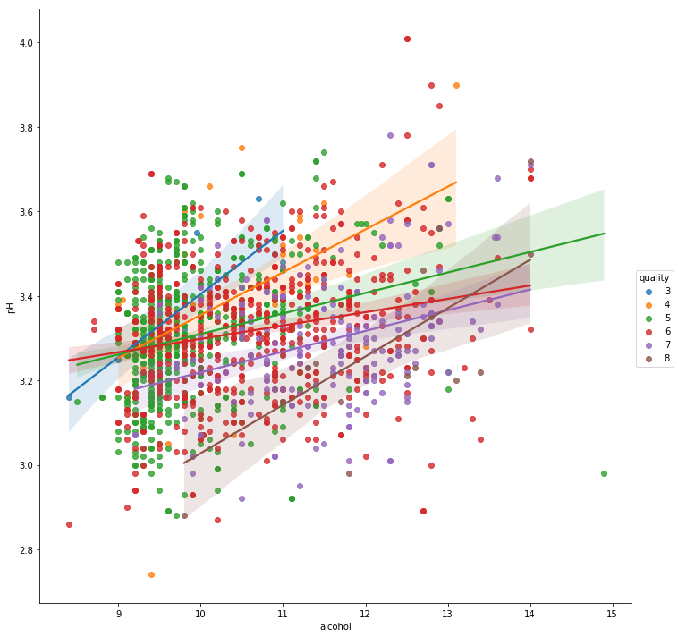

```python
g = sns.lmplot(x="alcohol", y="pH", hue="quality",
               truncate=True, size=10, data=df)
```

**不同质量下，alcohol和pH成正相关，在不同质量下的相关度变化较大。**

## 查看density，alcohol，quality间的关系：

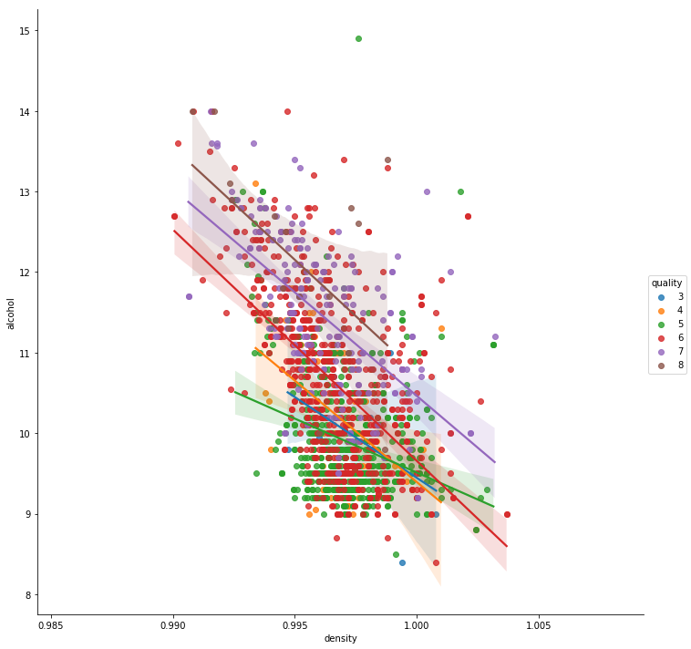

```python
g = sns.lmplot(x="density", y="alcohol", hue="quality",
               truncate=True, size=10, data=df)
```

**不同质量下，density和alcohol呈负相关**

# 多变量分析

## 探讨你在这部分探究中观察到的一些关系。通过观察感兴趣的特性，是否存在相互促进的特性？

**酒精度高的质量高，与pH关系不大。**

## 这些特性之间是否存在有趣或惊人的联系呢？

**同一游离酸度下，柠檬酸高的质量低**

# 定稿图与总结

## 绘图一

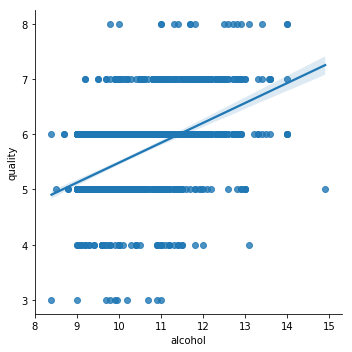

```python
g = sns.lmplot(x="alcohol", y= "quality", truncate=True, size=5,data=df)
```

```python
# alcohol与quality相关系数
df['alcohol'].corr(df['quality'])
```

```
0.4761663240011362
```

## 描述一

**酒精度与质量成正相关,酒精度越高，其质量评分也越高**

## 绘图二

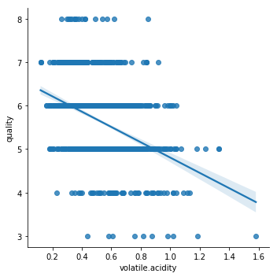

```python
g = sns.lmplot(x="volatile.acidity", y= "quality", truncate=True, size=5,data=df)
```

**质量与游离酸度成明显负相关，游离酸度越高，其质量评分越低。**

## 绘图三

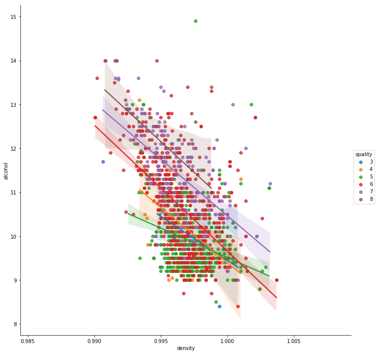

```python
g = sns.lmplot(x="density", y="alcohol", hue="quality",
               truncate=True, size=10, data=df)
```

```python
# density和alcohol的相关系数
df['density'].corr(df['alcohol'])
```

```
-0.4961797702417012
```

## 描述三

**不同质量下，density和alcohol呈负相关，相关系数-0.5**